# 9月决策树与Stacking78.36%

### 2、训练模型

#### （1）线性svm

https://scikit-learn.org/stable/modules/generated/sklearn.linear_model.SGDClassifier.html#sklearn.linear_model.SGDClassifier

```python
lsvm_clf.fit(inputs_minMax,Train_Data['标签'])
```

```
SGDClassifier(alpha=0.0001, average=False, class_weight=None,
       early_stopping=False, epsilon=0.1, eta0=1, fit_intercept=True,
       l1_ratio=0.15, learning_rate='constant', loss='hinge',
       max_iter=1000, n_iter=None, n_iter_no_change=5, n_jobs=None,
       penalty='l2', power_t=0.5, random_state=111, shuffle=True, tol=None,
       validation_fraction=0.1, verbose=0, warm_start=False)
```

#### (2)感知机

```python
perception_clf.fit(inputs_minMax,Train_Data['标签'])
```

```
SGDClassifier(alpha=0.0001, average=False, class_weight=None,
       early_stopping=False, epsilon=0.1, eta0=1, fit_intercept=True,
       l1_ratio=0.15, learning_rate='constant', loss='perceptron',
       max_iter=1000, n_iter=None, n_iter_no_change=5, n_jobs=None,
       penalty=None, power_t=0.5, random_state=111, shuffle=True, tol=None,
       validation_fraction=0.1, verbose=0, warm_start=False)
```

#### (3)逻辑回归

```python
lr_clf.fit(inputs_minMax,Train_Data['标签'])
```

```
SGDClassifier(alpha=0.0001, average=False, class_weight=None,
       early_stopping=False, epsilon=0.1, eta0=1, fit_intercept=True,
       l1_ratio=0.15, learning_rate='constant', loss='log', max_iter=1000,
       n_iter=None, n_iter_no_change=5, n_jobs=None, penalty=None,
       power_t=0.5, random_state=111, shuffle=True, tol=None,
       validation_fraction=0.1, verbose=0, warm_start=False)
```

#### (4)决策树

```python
deci_clf.fit(inputs_minMax,Train_Data['标签'])
```

```
DecisionTreeClassifier(class_weight=None, criterion='gini', max_depth=None,
            max_features=None, max_leaf_nodes=None,
            min_impurity_decrease=0.0, min_impurity_split=None,
            min_samples_leaf=1, min_samples_split=2,
            min_weight_fraction_leaf=0.0, presort=False, random_state=30,
            splitter='best')
```

#### (5)K近邻

```python
knn_clf.fit(inputs_minMax,Train_Data['标签'])
```

```
KNeighborsClassifier(algorithm='auto', leaf_size=30, metric='minkowski',
           metric_params=None, n_jobs=None, n_neighbors=5, p=2,
           weights='uniform')
```

#### (6)贝叶斯

```python
bayes_clf.fit(inputs_minMax,Train_Data['标签'])
```

```
GaussianNB(priors=None, var_smoothing=1e-09)
```

#### (7)随机森林

```python
rf_clf.fit(inputs_minMax,Train_Data['标签'])
```

```
RandomForestClassifier(bootstrap=True, class_weight=None, criterion='gini',
            max_depth=3, max_features='auto', max_leaf_nodes=None,
            min_impurity_decrease=0.0, min_impurity_split=None,
            min_samples_leaf=1, min_samples_split=2,
            min_weight_fraction_leaf=0.0, n_estimators=10, n_jobs=None,
            oob_score=False, random_state=111, verbose=0, warm_start=False)
```

#### (8)Stacking

```python
sclf.fit(inputs_minMax,Train_Data['标签'])
```

```
StackingClassifier(average_probas=False,
          classifiers=[SGDClassifier(alpha=0.0001, average=False, class_weight=None,
       early_stopping=False, epsilon=0.1, eta0=1, fit_intercept=True,
       l1_ratio=0.15, learning_rate='constant', loss='hinge',
       max_iter=1000, n_iter=None, n_iter_no_change=5, n_jobs=None,
       penalty='l2', powe...         min_weight_fraction_leaf=0.0, presort=False, random_state=30,
            splitter='best')],
          drop_proba_col=None, fit_base_estimators=True,
          meta_classifier=LogisticRegression(C=1.0, class_weight=None, dual=False, fit_intercept=True,
          intercept_scaling=1, max_iter=100, multi_class='warn',
          n_jobs=None, penalty='l2', random_state=None, solver='warn',
          tol=0.0001, verbose=0, warm_start=False),
          store_train_meta_features=False, use_clones=True,
          use_features_in_secondary=False, use_probas=False, verbose=0)
```

#### (9)SVC

```python
svc_clf.fit(inputs_minMax,Train_Data['标签'])
```

```
Pipeline(memory=None,
     steps=[('standardscaler', StandardScaler(copy=True, with_mean=True, with_std=True)), ('linearsvc', LinearSVC(C=1.0, class_weight=None, dual=True, fit_intercept=True,
     intercept_scaling=1, loss='squared_hinge', max_iter=1000,
     multi_class='ovr', penalty='l2', random_state=111, tol=1e-05,
     verbose=0))])
```

## 三、测试集数据处理

## 1、读数据、拼接文件

```python
CALIPSO_CLEAR_FY_1 = pd.read_csv('CALIPSO_CLEAR_FY_1.csv',encoding='gbk')
CALIPSO_CLEAR_FY_2 = pd.read_csv('CALIPSO_CLEAR_FY_2.csv',encoding='gbk')

CALIPSO_CLOUD_FY_1 = pd.read_csv('CALIPSO_CLOUD_FY_1.csv',encoding='gbk')
CALIPSO_CLOUD_FY_2 = pd.read_csv('CALIPSO_CLOUD_FY_2.csv',encoding='gbk')
```

```python
print(CALIPSO_CLEAR_FY_1.shape)
print(CALIPSO_CLEAR_FY_2.shape)
```

```
(962200, 24)
(545336, 24)
```

```python
print(CALIPSO_CLOUD_FY_1.shape)
print(CALIPSO_CLOUD_FY_2.shape)
```

```
(2412325, 24)
(1305528, 24)
```

```python
#气溶胶
CALIPSO_CLEAR_FY = pd.concat([CALIPSO_CLEAR_FY_1,CALIPSO_CLEAR_FY_2])
#云
CALIPSO_CLOUD_FY = pd.concat([CALIPSO_CLOUD_FY_1,CALIPSO_CLOUD_FY_2])
```

```python
print(CALIPSO_CLEAR_FY.shape)
print(CALIPSO_CLOUD_FY.shape)
```

```
(1507536, 24)
(3717853, 24)
```

### 2、筛选符合要求的数据

```python
#以风云卫星1为基准，提取出大于0的所有记录
CALIPSO_CLEAR_FY = CALIPSO_CLEAR_FY[CALIPSO_CLEAR_FY['风云卫星1']>0]
CALIPSO_CLOUD_FY = CALIPSO_CLOUD_FY[CALIPSO_CLOUD_FY['风云卫星1']>0]
```

```python
CALIPSO_CLEAR_FY.shape
```

```
(1501594, 24)
```

```python
CALIPSO_CLOUD_FY.shape
```

```
(3701898, 24)
```

### 3、确定特征 、创建标签

```python
#测试集需要用到所有特征，一共24个，故不用像训练集一样进行提取
CALIPSO_CLEAR_FY['标签'] = 0
CALIPSO_CLOUD_FY['标签'] = 1
```

```python
#连接气溶胶与云的训练集为一个整体,气溶胶数据在上，云数据在下
Valid_Data  =  pd.concat([CALIPSO_CLEAR_FY,CALIPSO_CLOUD_FY])
```

```python
Valid_Data.head(2)
```

|  | 风云卫星1 | 风云卫星2 | 风云卫星3 | 风云卫星4 | 风云卫星5 | 风云卫星6 | 风云卫星7 | 20波段 | 21波段 | 22波段 | ... | 地表类型 | 纬度 | 经度 | 卫星方位角 | 卫星天顶角 | 太阳方位角 | 太阳天顶角 | 观测时的月份 | 像素记录flag | 标签 |
| --- | --- | --- | --- | --- | --- | --- | --- | --- | --- | --- | --- | --- | --- | --- | --- | --- | --- | --- | --- | --- | --- |
| 0 | 0.179932 | 0.129485 | 0.104157 | 0.089074 | 0.011025 | 0.072610 | 0.054900 | 298.002294 | 288.960281 | 266.020651 | ... | 7.0 | 18.204229 | 130.365219 | 263.68 | 51.01 | 215.64 | 50.01 | 1.0 | -1.0 | 0 |
| 1 | 0.201474 | 0.150603 | 0.123863 | 0.112738 | 0.011466 | 0.122513 | 0.093808 | 298.506009 | 288.300626 | 265.822454 | ... | 7.0 | 18.217369 | 130.363647 | 263.67 | 51.01 | 215.63 | 50.02 | 1.0 | -1.0 | 0 |

2 rows × 25 columns

```python
#更改地表标签数据，其值不为1的全部替换为0
Valid_Data['地表类型'][Valid_Data['地表类型']!=1] = 0
```

```python
Valid_Data.head(2)
```

|  | 风云卫星1 | 风云卫星2 | 风云卫星3 | 风云卫星4 | 风云卫星5 | 风云卫星6 | 风云卫星7 | 20波段 | 21波段 | 22波段 | ... | 地表类型 | 纬度 | 经度 | 卫星方位角 | 卫星天顶角 | 太阳方位角 | 太阳天顶角 | 观测时的月份 | 像素记录flag | 标签 |
| --- | --- | --- | --- | --- | --- | --- | --- | --- | --- | --- | --- | --- | --- | --- | --- | --- | --- | --- | --- | --- | --- |
| 0 | 0.179932 | 0.129485 | 0.104157 | 0.089074 | 0.011025 | 0.072610 | 0.054900 | 298.002294 | 288.960281 | 266.020651 | ... | 0.0 | 18.204229 | 130.365219 | 263.68 | 51.01 | 215.64 | 50.01 | 1.0 | -1.0 | 0 |
| 1 | 0.201474 | 0.150603 | 0.123863 | 0.112738 | 0.011466 | 0.122513 | 0.093808 | 298.506009 | 288.300626 | 265.822454 | ... | 0.0 | 18.217369 | 130.363647 | 263.67 | 51.01 | 215.63 | 50.02 | 1.0 | -1.0 | 0 |

2 rows × 25 columns

```python
import math
c = Valid_Data['太阳天顶角']*math.pi/180
cos = c.apply(lambda x:math.cos(x))
Valid_Data.iloc[:,:7] = Valid_Data.iloc[:,:7].div(cos,axis=0)
Valid_Data.head()
```

|  | 风云卫星1 | 风云卫星2 | 风云卫星3 | 风云卫星4 | 风云卫星5 | 风云卫星6 | 风云卫星7 | 20波段 | 21波段 | 22波段 | ... | 地表类型 | 纬度 | 经度 | 卫星方位角 | 卫星天顶角 | 太阳方位角 | 太阳天顶角 | 观测时的月份 | 像素记录flag | 标签 |
| --- | --- | --- | --- | --- | --- | --- | --- | --- | --- | --- | --- | --- | --- | --- | --- | --- | --- | --- | --- | --- | --- |
| 0 | 0.279983 | 0.201485 | 0.162074 | 0.138603 | 0.017156 | 0.112985 | 0.085426 | 298.002294 | 288.960281 | 266.020651 | ... | 0.0 | 18.204229 | 130.365219 | 263.68 | 51.01 | 215.64 | 50.01 | 1.0 | -1.0 | 0 |
| 1 | 0.313568 | 0.234394 | 0.192777 | 0.175463 | 0.017845 | 0.190676 | 0.146001 | 298.506009 | 288.300626 | 265.822454 | ... | 0.0 | 18.217369 | 130.363647 | 263.67 | 51.01 | 215.63 | 50.02 | 1.0 | -1.0 | 0 |
| 2 | 0.315744 | 0.248526 | 0.196220 | 0.188242 | 0.020597 | 0.124328 | 0.081777 | 296.668879 | 288.853288 | 265.921654 | ... | 0.0 | 18.254147 | 130.352829 | 263.71 | 51.01 | 215.61 | 50.04 | 1.0 | -2.0 | 0 |
| 3 | 0.281035 | 0.201252 | 0.162629 | 0.139565 | 0.019572 | 0.244351 | 0.172013 | 298.279423 | 287.742716 | 266.178630 | ... | 0.0 | 18.267286 | 130.351242 | 263.70 | 51.01 | 215.60 | 50.05 | 1.0 | -2.0 | 0 |
| 4 | 0.273329 | 0.192990 | 0.154868 | 0.126699 | 0.017149 | 0.131036 | 0.105900 | 298.057940 | 288.740223 | 266.218045 | ... | 0.0 | 18.202343 | 130.348145 | 263.67 | 50.94 | 215.63 | 49.99 | 1.0 | -1.0 | 0 |

5 rows × 25 columns

```python
Valid_Data.columns
```

```
Index(['风云卫星1', '风云卫星2', '风云卫星3', '风云卫星4', '风云卫星5', '风云卫星6', '风云卫星7', '20波段',
       '21波段', '22波段', '23波段', '24波段', '25波段', '地表高程', '海陆flag', '地表类型', '纬度',
       '经度', '卫星方位角', '卫星天顶角', '太阳方位角', '太阳天顶角', '观测时的月份', '像素记录flag', '标签'],
      dtype='object')
```

```python
Valid_Data['观测时的月份'].value_counts()
```

```
1.0     581919
2.0     581844
3.0     565861
5.0     559586
6.0     552407
12.0    533846
4.0     511011
11.0    402379
10.0    294489
9.0     275630
8.0     242292
7.0     102228
Name: 观测时的月份, dtype: int64
```

```python
Valid_Data.shape
```

```
(5203492, 25)
```

#### (1)将相对方位角放入验证数据集,作为验证数据集的第一列

```python
# 当太阳方位角大于180度时，减去360度，即将太阳方位角范围置于[-180,180]
Valid_Data['太阳方位角'][Valid_Data['太阳方位角']>180] -= 360

# 对卫星方位角进行与相对方位角同样的处理
Valid_Data['卫星方位角'][Valid_Data['卫星方位角']>180] -= 360
```

```python
Valid_Data.head()
```

|  | 风云卫星1 | 风云卫星2 | 风云卫星3 | 风云卫星4 | 风云卫星5 | 风云卫星6 | 风云卫星7 | 20波段 | 21波段 | 22波段 | ... | 地表类型 | 纬度 | 经度 | 卫星方位角 | 卫星天顶角 | 太阳方位角 | 太阳天顶角 | 观测时的月份 | 像素记录flag | 标签 |
| --- | --- | --- | --- | --- | --- | --- | --- | --- | --- | --- | --- | --- | --- | --- | --- | --- | --- | --- | --- | --- | --- |
| 0 | 0.279983 | 0.201485 | 0.162074 | 0.138603 | 0.017156 | 0.112985 | 0.085426 | 298.002294 | 288.960281 | 266.020651 | ... | 0.0 | 18.204229 | 130.365219 | -96.32 | 51.01 | -144.36 | 50.01 | 1.0 | -1.0 | 0 |
| 1 | 0.313568 | 0.234394 | 0.192777 | 0.175463 | 0.017845 | 0.190676 | 0.146001 | 298.506009 | 288.300626 | 265.822454 | ... | 0.0 | 18.217369 | 130.363647 | -96.33 | 51.01 | -144.37 | 50.02 | 1.0 | -1.0 | 0 |
| 2 | 0.315744 | 0.248526 | 0.196220 | 0.188242 | 0.020597 | 0.124328 | 0.081777 | 296.668879 | 288.853288 | 265.921654 | ... | 0.0 | 18.254147 | 130.352829 | -96.29 | 51.01 | -144.39 | 50.04 | 1.0 | -2.0 | 0 |
| 3 | 0.281035 | 0.201252 | 0.162629 | 0.139565 | 0.019572 | 0.244351 | 0.172013 | 298.279423 | 287.742716 | 266.178630 | ... | 0.0 | 18.267286 | 130.351242 | -96.30 | 51.01 | -144.40 | 50.05 | 1.0 | -2.0 | 0 |
| 4 | 0.273329 | 0.192990 | 0.154868 | 0.126699 | 0.017149 | 0.131036 | 0.105900 | 298.057940 | 288.740223 | 266.218045 | ... | 0.0 | 18.202343 | 130.348145 | -96.33 | 50.94 | -144.37 | 49.99 | 1.0 | -1.0 | 0 |

5 rows × 25 columns

```python
Valid_Data['标签'].value_counts()
```

```
1    3701898
0    1501594
Name: 标签, dtype: int64
```

```python
#原数据中月份以float64进行存储，将其改为int32
#原数据中月份以float64进行存储，将其改为int32
Valid_Data['观测时的月份'] =Valid_Data['观测时的月份'].astype('int32')
```

#### (2)分月份

```python
# Valid_Jan = Valid_Data[Valid_Data['观测时的月份']==1]
# Valid_Feb = Valid_Data[Valid_Data['观测时的月份']==2]
# Valid_Mar = Valid_Data[Valid_Data['观测时的月份']==3]
# Valid_Apr = Valid_Data[Valid_Data['观测时的月份']==4]
# Valid_May = Valid_Data[Valid_Data['观测时的月份']==5]
# Valid_Jun = Valid_Data[Valid_Data['观测时的月份']==6]
# Valid_Jul = Valid_Data[Valid_Data['观测时的月份']==7]
# Valid_Aug = Valid_Data[Valid_Data['观测时的月份']==8]
Valid_Sep = Valid_Data[Valid_Data['观测时的月份']==9]
# Valid_Oct = Valid_Data[Valid_Data['观测时的月份']==10]
# Valid_Nov = Valid_Data[Valid_Data['观测时的月份']==11]
# Valid_Dec = Valid_Data[Valid_Data['观测时的月份']==12]
```

开始计算相对方位角 = 卫星方位角-太阳方位角

```python
#实际将相对方位角的范围改变范围，为[0,180]
# Phi>360这行代码其实是废话，因为Phi>180这行又处理了，为了完整性还是写上去吧！！
Phi = abs(Valid_Sep['卫星方位角'] - Valid_Sep['太阳方位角'] - 180)
Phi[Phi>360] = Phi[Phi>360] % 360  #%将相对方位角得范围设置为[0,360]
Phi[Phi>180] = 360 -  Phi[Phi>180]#提取相对方位角大于180的值，范围为[0,180]
```

```python
Phi[:2]
```

```
66748    119.22
66749    119.25
dtype: float64
```

```python
Inputs = pd.DataFrame(Phi,columns=['相对方位角'])
```

```python
Inputs.head(2)
```

|  | 相对方位角 |
| --- | --- |
| 66748 | 119.22 |
| 66749 | 119.25 |

#### (3)将卫星天顶角，太阳天顶角，风云卫星1-7个波段反射率放入验证数据集

```python
Inputs['卫星天顶角'] = Valid_Sep['卫星天顶角']
Inputs['太阳天顶角'] = Valid_Sep['太阳天顶角']
Inputs['风云卫星1'] = Valid_Sep['风云卫星1']
Inputs['风云卫星2'] = Valid_Sep['风云卫星2']
Inputs['风云卫星3'] = Valid_Sep['风云卫星3']
Inputs['风云卫星4'] = Valid_Sep['风云卫星4']
Inputs['风云卫星5'] = Valid_Sep['风云卫星5']
Inputs['风云卫星6'] = Valid_Sep['风云卫星6']
Inputs['风云卫星7'] = Valid_Sep['风云卫星7']
```

```python
Inputs.head(2)
```

|  | 相对方位角 | 卫星天顶角 | 太阳天顶角 | 风云卫星1 | 风云卫星2 | 风云卫星3 | 风云卫星4 | 风云卫星5 | 风云卫星6 | 风云卫星7 |
| --- | --- | --- | --- | --- | --- | --- | --- | --- | --- | --- |
| 66748 | 119.22 | 15.04 | 50.26 | 0.095139 | 0.084421 | 0.060056 | 0.306302 | 0.002632 | 0.150029 | 0.054871 |
| 66749 | 119.25 | 15.04 | 50.26 | 0.097479 | 0.089009 | 0.069675 | 0.301052 | 0.002632 | 0.158475 | 0.058401 |

#### (4)将地表高程放入验证数据集，米换算成千米

```python
Inputs['地表高程'] = Valid_Sep['地表高程']/1000
```

```python
Inputs.tail(2)
```

|  | 相对方位角 | 卫星天顶角 | 太阳天顶角 | 风云卫星1 | 风云卫星2 | 风云卫星3 | 风云卫星4 | 风云卫星5 | 风云卫星6 | 风云卫星7 | 地表高程 |
| --- | --- | --- | --- | --- | --- | --- | --- | --- | --- | --- | --- |
| 477985 | 156.76 | 57.17 | 37.75 | 0.173793 | 0.100038 | 0.054881 | 0.025012 | 0.004039 | 0.008765 | 0.004208 | 0.0 |
| 477986 | 156.75 | 57.16 | 37.75 | 0.173793 | 0.100038 | 0.054881 | 0.025344 | 0.003771 | 0.008450 | 0.003681 | 0.0 |

```python
Targets = Valid_Sep['标签']
```

```python
Valid = pd.concat([Inputs,Targets],axis=1)
```

```python
Valid.head(2)
```

|  | 相对方位角 | 卫星天顶角 | 太阳天顶角 | 风云卫星1 | 风云卫星2 | 风云卫星3 | 风云卫星4 | 风云卫星5 | 风云卫星6 | 风云卫星7 | 地表高程 | 标签 |
| --- | --- | --- | --- | --- | --- | --- | --- | --- | --- | --- | --- | --- |
| 66748 | 119.22 | 15.04 | 50.26 | 0.095139 | 0.084421 | 0.060056 | 0.306302 | 0.002632 | 0.150029 | 0.054871 | 0.040 | 0 |
| 66749 | 119.25 | 15.04 | 50.26 | 0.097479 | 0.089009 | 0.069675 | 0.301052 | 0.002632 | 0.158475 | 0.058401 | 0.048 | 0 |

```python
Valid.head(2).iloc[:,:11]
```

|  | 相对方位角 | 卫星天顶角 | 太阳天顶角 | 风云卫星1 | 风云卫星2 | 风云卫星3 | 风云卫星4 | 风云卫星5 | 风云卫星6 | 风云卫星7 | 地表高程 |
| --- | --- | --- | --- | --- | --- | --- | --- | --- | --- | --- | --- |
| 66748 | 119.22 | 15.04 | 50.26 | 0.095139 | 0.084421 | 0.060056 | 0.306302 | 0.002632 | 0.150029 | 0.054871 | 0.040 |
| 66749 | 119.25 | 15.04 | 50.26 | 0.097479 | 0.089009 | 0.069675 | 0.301052 | 0.002632 | 0.158475 | 0.058401 | 0.048 |

```python
Valid.shape
```

```
(275630, 12)
```

### 3、丢失测试集中的缺失值数据用于归一化

```python
Valid = Valid.replace([np.inf, -np.inf], np.nan).dropna()
```

```python
Valid.shape
```

```
(275630, 12)
```

## 四、评估模型

#### (1)线性svm

```python
print('linear_svm ACC：','{:.2%}'.format(round(lsvm_clf.score(Valid.iloc[:,:11],Valid['标签']),4)))
```

```
linear_svm ACC： 68.31%
```

#### (2)感知机

```python
print('perception ACC：','{:.2%}'.format(round(perception_clf.score(Valid.iloc[:,:11],Valid['标签']),4)))
```

```
perception ACC： 74.09%
```

#### (3)逻辑回归

```python
print('lr ACC：','{:.2%}'.format(round(lr_clf.score(Valid.iloc[:,:11],Valid['标签']),4)))
```

```
lr ACC： 74.17%
```

#### (4)决策树

```python
print('deci_clf ACC：','{:.2%}'.format(round(deci_clf.score(Valid.iloc[:,:11],Valid['标签']),4)))
```

```
deci_clf ACC： 78.36%
```

#### (5)K近邻

```python
print('knn_clf ACC：','{:.2%}'.format(round(knn_clf.score(Valid.iloc[:,:11],Valid['标签']),4)))
```

```
knn_clf ACC： 54.98%
```

#### (6)贝叶斯

```python
print('bayes_clf ACC：','{:.2%}'.format(round(bayes_clf.score(Valid.iloc[:,:11],Valid['标签']),4)))
```

```
bayes_clf ACC： 66.99%
```

#### (7)随机森林

```python
print('rf_clf ACC：','{:.2%}'.format(round(rf_clf.score(Valid.iloc[:,:11],Valid['标签']),4)))
```

```
rf_clf ACC： 77.90%
```

#### (8)Stacking

```python
print('sclf ACC：','{:.2%}'.format(round(sclf.score(Valid.iloc[:,:11],Valid['标签']),4)))
```

```
sclf ACC： 78.36%
```

#### (9)SVC

```python
print('svc ACC：','{:.2%}'.format(round(svc_clf.score(Valid.iloc[:,:11],Valid['标签']),4)))
```

```
svc ACC： 65.49%
```

## 五、使用混淆矩阵评估分类效果

### 1、生成测试集的混淆矩阵

```python
Y_deci_clf_pred = deci_clf.predict(Valid.iloc[:,:11])
```

```python
Y_deci_clf_pred
```

```
array([0, 0, 0, ..., 0, 0, 0], dtype=int64)
```

```python
from sklearn.metrics import confusion_matrix
confusion_matrix = confusion_matrix(Valid['标签'].values,Y_deci_clf_pred)
confusion_matrix
```

```
array([[ 59453,  15962],
       [ 43687, 156528]], dtype=int64)
```

### 2、绘制混淆矩阵热力图

```python
# sclf.classes_
```

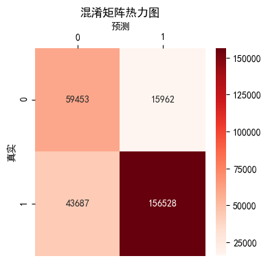

```python
import seaborn as sns
import matplotlib.pyplot as plt
#正常显示中文
plt.rcParams['font.sans-serif'] = ['SimHei']
plt.rcParams['axes.unicode_minus'] = False
#设置图片的清晰度
plt.rcParams['figure.dpi'] = 100

fig,ax = plt.subplots(figsize=(4,4))
#绘制热力图
ax=sns.heatmap(confusion_matrix,cmap ="Reds",annot=True,fmt='d',
               xticklabels = deci_clf.classes_,yticklabels = deci_clf.classes_)
ax.set_ylabel('真实')
ax.set_xlabel('预测')
ax.xaxis.set_label_position('top')
ax.xaxis.tick_top()
ax.set_title('混淆矩阵热力图')
```

## 六、精度对比图

```
(50, 80)
```

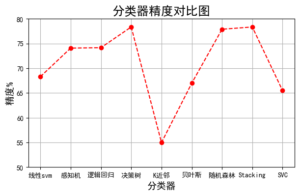

```python
CLFS =  ['线性svm','感知机','逻辑回归','决策树','K近邻','贝叶斯','随机森林','Stacking','SVC']
ACCS = [68.31,74.09,74.17,78.36,54.98,66.99,77.90,78.36,65.49]

# fig,ax = plt.subplots(figsize=(6,4))
plt.figure(figsize=(7,4))
plt.plot(CLFS,ACCS,'o--',color='red')
# ax.set_xticklabels(rotation=45)
plt.xlabel('分类器',fontsize=14)
plt.ylabel('精度%',fontsize=14)
plt.title('分类器精度对比图',fontsize=18)
plt.grid()
plt.ylim(50,80)
```